# Kings_markdown

Jonas Hoff

2023-10-03

## Mit kings dokument

I dette dokument vil jeg loade mine kings-data og plotte dem på et pænt søjlediagram

Jeg starter med at loade mine data og tildele dem et dataset kaldet “kings”

```r
library(tidyverse)

kings <- read.csv2(
  "C:/Users/dkman/Desktop/Uni/3_semester/TOM_Digitale_metoder/R/W38_intro_to_R/data/Kings.csv", na = "NA")
```

# Jeg formatterer variablene som datoer

og jeg laver vektoren “reign_time_years” som er hver konges regeringstid i år. NA-observationer er stadig NA og det er ok.

```r
kings$ReignStart1 <- as.Date(kings$ReignStart1, format="%Y-%m-%d")
kings$ReignEnd1 <- as.Date(kings$ReignEnd1, format="%Y-%m-%d")


reign_time_days <- as.numeric(difftime(kings$ReignEnd1, kings$ReignStart1, units = "days"))
reign_time_years <- reign_time_days/365.25
# Her kan I se de første 10
reign_time_years[1:10]
```

```
##  [1]        NA        NA        NA  4.000000 16.999316  7.000684  4.999316
##  [8] 27.000684  5.998631  6.521561
```

Jeg kombinerer kongernes navne fra mine kolonner “FirstName” “Title” og “Number” så dem der ikke har en titel ikke får NA indimellem fornavn og nummer. Alt bliver sepereret med et mellemrum :-)

```r
kings_combined_names <- ifelse(is.na(kings$Title),
                               paste(kings$FirstName, kings$Number, sep = " "),
                               paste(kings$FirstName, kings$Title, kings$Number, sep = " ")
)
# Jeg viser de første 10
kings_combined_names[1:10]
```

```
##  [1] "Gorm den Gamle 1"   "Harald Blaatand 1"  "Svend Tveskaeg 1"
##  [4] "Harald 2"           "Knud den Store 1"   "Hardeknud 1"
##  [7] "Magnus den Gode 1"  "Svend 2"            "Harald Hen 3"
## [10] "Knud den Hellige 2"
```

Jeg tildeler dem som objekterne x og y til mit plot

```r
y <- reign_time_years
x <- kings_combined_names
```

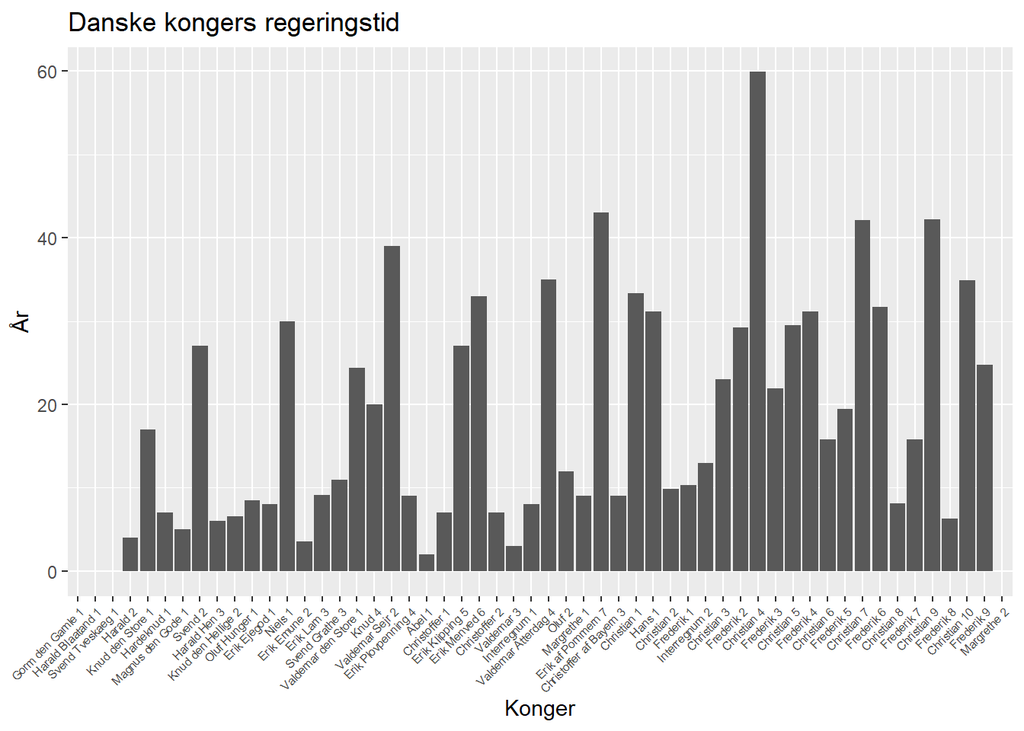

```r
p <- ggplot(data = NULL, aes(
    x = reorder(kings_combined_names, kings$ReignEnd1),
    y = y)) +
  geom_col() +
  labs(x = "Konger", y = "År") +
  scale_x_discrete(drop = FALSE) +
  ggtitle("Danske kongers regeringstid") +
  theme(
    axis.text.x = element_text(angle = 45, hjust = 1, size = 5.5),
    legend.position = "none"
    )

p
```

Jeg fjerner legenden ude til højre så man ikke skal se en klasse for hvert kongenavn